# warmTreat

RicardoQi

2022-04-02

This code is written by Runzi Qi from Group 5 to determine that do plants transplanted to warmer ranged seed earlier than plants in cooler ranges, and does this change between NK and HB.

## Data import

the package ggplot() is loaded for future use of plots, and csv file of experiment data is imported.

```r
library(ggplot2)
library(cowplot)
HB <- read.csv("C:\\Users\\qi199\\Documents\\432_Group5\\Project\\Data\\HargreavesEcolLett data prop&LTFHB.csv")
NK <- read.csv("C:\\Users\\qi199\\Documents\\432_Group5\\Project\\Data\\HargreavesEcolLett data prop&LTFNK.csv")
```

## Seed emergence vs. Range

The first section of plot is created to show the potential relationship between seed emergence(nEmzt) and range of plant habitats.

```r
#plot for HB created
HB_1 <- ggplot(HB,
       aes(x = Source,
           fill = nEmzt)) +
  geom_bar(position = position_dodge(width=0.8))+
  geom_text(aes(label=..count..), stat= "count", position=position_dodge(width=0.9), vjust=-0.25)+
  ylab("Seed emergence (# of nEmzt)")
#plot for NK created
NK_1 <- ggplot(NK,
       aes(x = Source,
           fill = nEmzt)) +
  geom_bar(position = position_dodge(width=0.8))+
  ggtitle("Seed emergence for transplanted plants originated from NK")+
  geom_text(aes(label=..count..), stat= "count", position=position_dodge(width=0.9), vjust=-0.25)+
  ylab("")+
  theme(axis.text.y=element_blank(),
        axis.ticks.y=element_blank())
```

Then, two plots are arranged side-to-side for the purpose of comparison.

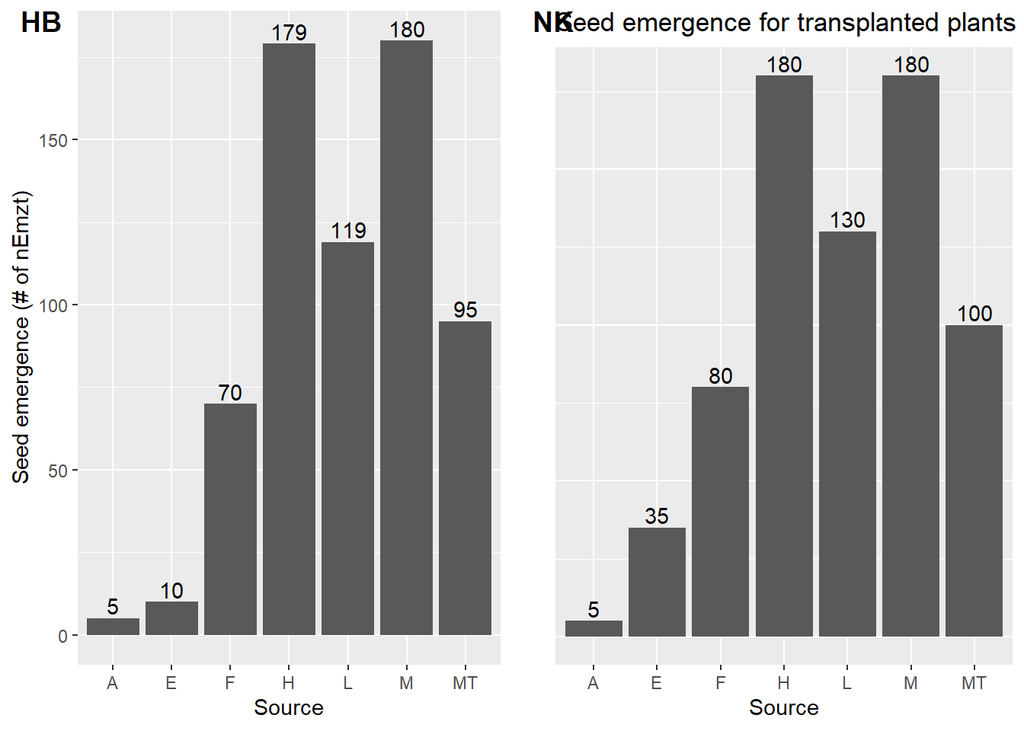

```r
plot_grid(HB_1, NK_1, labels = c('HB','NK'), ncol=2)
```

As seen in the plot, there is an obvious increase in the number of plant emergence at source E, which stands for the absolute high-elevation range edge, in NK comparing to HB. Increase in plant emergence are also seen in F (Fortress Mountain), L (low-elevation from that transet), and MT (neighbouring Moose Mountain above 2000m).

## Group by transplant location

In this section, groups are categorized by transplant location (“treat”, control or warming chambers) using similar codes above.

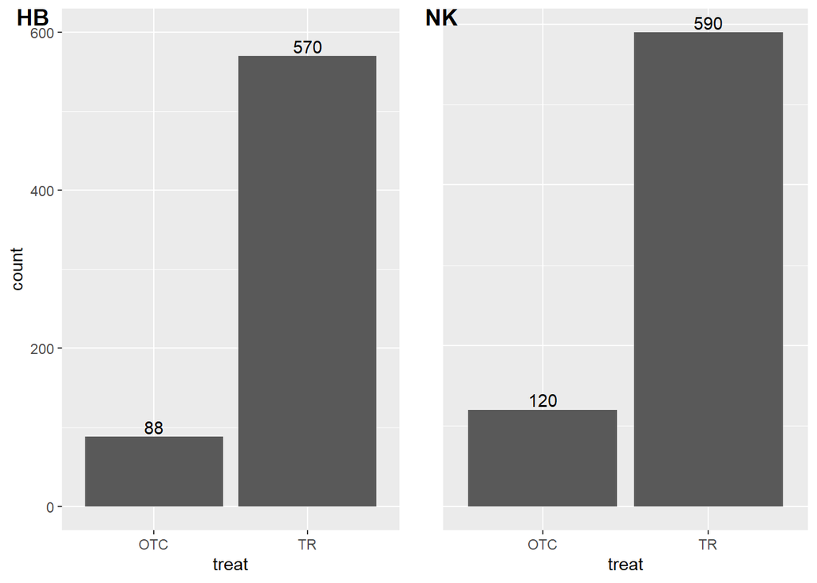

```r
HB_2 <- ggplot(HB, aes(treat))+
  geom_bar()+
  scale_y_continuous(limits=c(0, 600))+
  geom_text(aes(label=..count..), stat= "count", position=position_dodge(width=0.9), vjust=-0.25)

NK_2 <- ggplot(NK, aes(treat))+
  geom_bar()+
  ylab("")+
  geom_text(aes(label=..count..), stat= "count", position=position_dodge(width=0.9), vjust=-0.25)+
  theme(axis.text.y=element_blank(),
        axis.ticks.y=element_blank())
plot_grid(HB_2, NK_2, labels = c('HB','NK'), ncol=2)
```